# Opdracht 19

Create a cluster module on the penguins dataset

- Use the pairplot() function on the penguins dataset. Do you visually notice any clusters? How many clusters do you think there are?
- Use the KMeans algorithm to create a cluster module. Apply this model to the dataset to create an extra column "cluster" just like we did for the iris dataset above
- Calculate the Silhouette Coefficient for your clustering. Play around with features and n_clusters to search for better results. Keep the cluster model with the highest Silhouette Coefficient.
- Use the pairplot(hue="cluster") function to observe how the model has clustered the data
- We know the species of each penguin. Use a contingency table to reveal the relation between the cluster results and the species. Is there an exact match? Are there any species which ended up in the same cluster? If so, what does it mean that they ended up in the same cluster

```python
import seaborn as sns

from matplotlib import pyplot as plt

from sklearn.cluster import KMeans

from sklearn import metrics
from sklearn.metrics import pairwise_distances
```

```python
pg = sns.load_dataset("penguins")
pg = pg.dropna()

pg.head()
```

|  | species | island | bill_length_mm | bill_depth_mm | flipper_length_mm | body_mass_g | sex |
| --- | --- | --- | --- | --- | --- | --- | --- |
| 0 | Adelie | Torgersen | 39.1 | 18.7 | 181.0 | 3750.0 | Male |
| 1 | Adelie | Torgersen | 39.5 | 17.4 | 186.0 | 3800.0 | Female |
| 2 | Adelie | Torgersen | 40.3 | 18.0 | 195.0 | 3250.0 | Female |
| 4 | Adelie | Torgersen | 36.7 | 19.3 | 193.0 | 3450.0 | Female |
| 5 | Adelie | Torgersen | 39.3 | 20.6 | 190.0 | 3650.0 | Male |

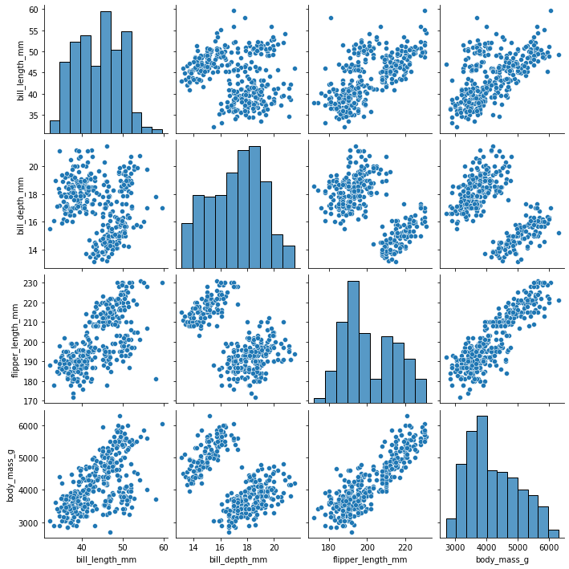

```python
sns.pairplot(pg)
```

```python
features = ['bill_length_mm', 'bill_depth_mm', 'body_mass_g']
km = KMeans(n_clusters=3, random_state = 42).fit(pg[features])
```

```python
pg["cluster"] = km.predict(pg[features])
pg.head()
```

|  | species | island | bill_length_mm | bill_depth_mm | flipper_length_mm | body_mass_g | sex | cluster |
| --- | --- | --- | --- | --- | --- | --- | --- | --- |
| 0 | Adelie | Torgersen | 39.1 | 18.7 | 181.0 | 3750.0 | Male | 2 |
| 1 | Adelie | Torgersen | 39.5 | 17.4 | 186.0 | 3800.0 | Female | 2 |
| 2 | Adelie | Torgersen | 40.3 | 18.0 | 195.0 | 3250.0 | Female | 2 |
| 4 | Adelie | Torgersen | 36.7 | 19.3 | 193.0 | 3450.0 | Female | 2 |
| 5 | Adelie | Torgersen | 39.3 | 20.6 | 190.0 | 3650.0 | Male | 2 |

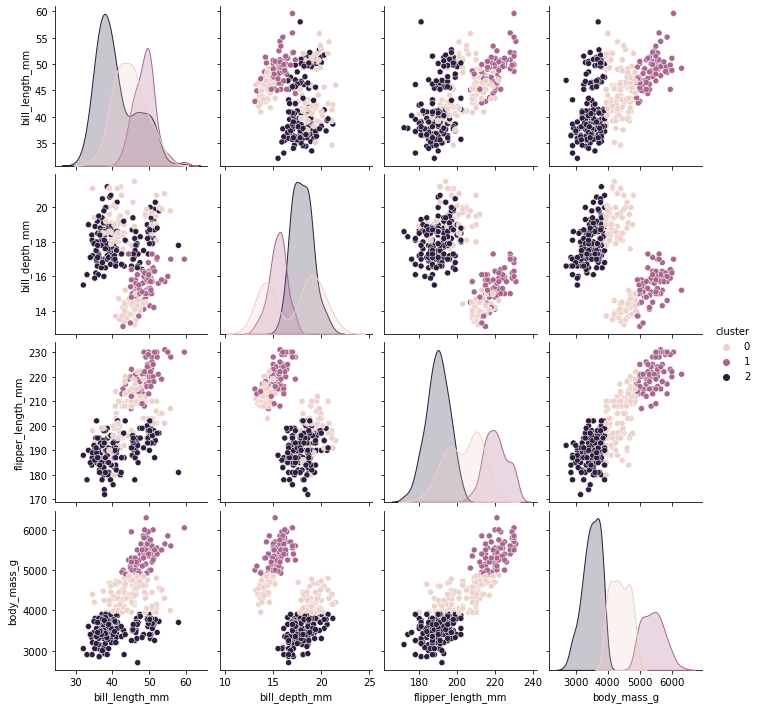

```python
sns.pairplot(pg, hue="cluster")
```

Hierboven is de grafiek te zien met 3 clusters.

```python
metrics.silhouette_score(pg[features], km.labels_, metric='euclidean')
```

```
0.5657612705387023
```

```python
km.cluster_centers_
```

```
array([[  44.66146789,   17.16238532, 4378.44036697],
       [  48.81351351,   15.47297297, 5407.09459459],
       [  41.12866667,   18.00133333, 3490.5       ]])
```

```python
 table = pg.groupby(['species', 'cluster']).size().unstack('cluster', fill_value=0)
table
```

| cluster species | 0 | 1 | 2 |
| --- | --- | --- | --- |
| Adelie | 44 | 0 | 102 |
| Chinstrap | 20 | 0 | 48 |
| Gentoo | 45 | 74 | 0 |

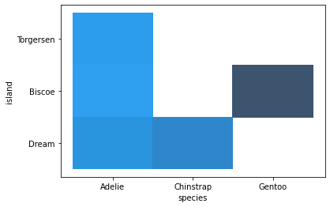

```python
sns.histplot(pg, x="species", y="island")
```